# Computational Analysis of Lung 1

```r
library(tidyverse)
source("src/utils.R")
source("src/plotting.R")
source("src/analysis.R")
source("src/manuscript.R")
```

## Load the Key Outputs from the Seurat Pipeline

In the sample directory: e.g., `/DATA_PATH/sample_name`, you can find the following:

- `analysis_res.tsv`: meta information for each cell, including t-SNE project and cluster labels
- `merged_umi/`: expression umi data including: `barcodes.tsv`, `features.tsv`m `matrix.mtx`
- `merged_umi_log/`: cell-sized normalized and log10-transformed data including: `barcodes.tsv`, `features.tsv`m `matrix.mtx`

Each row loaded in the meta_info corresponds to a cell, and the variables are plotted below:

- The t-SNE embeddings were pre-computed and used for 2-D visualization
- The high_clust_id and low_clust_id are the labels from graph-based clustering
- Other information such as gene/umi counts are also included

```r
# NOTE: SPECIFY HERE the directory where lung1 is saved
# ODIR <- "/DOWNLOAD/DATA/PATH"
sample_name <- "lung1"
sample_dir <- file.path(ODIR, sample_name)
meta_info <- load_meta_info(sample_dir)
dim(meta_info)
head(meta_info)
```

1. 7285

2. 8

| tSNE_1 | tSNE_2 | high_clust_id | low_clust_id | n_gene | n_umi | barcode | lib_id |
| --- | --- | --- | --- | --- | --- | --- | --- |
| 1.601315 | -16.007965 | 7 | 3 | 2119 | 7288 | AAACATACACTCAG-1 | 1 |
| 13.826523 | 4.654188 | 6 | 2 | 2729 | 11565 | AAACATACTTCATC-1 | 1 |
| 2.197714 | 13.327538 | 6 | 2 | 3315 | 13201 | AAACCGTGCACTGA-1 | 1 |
| -8.309753 | 8.505692 | 6 | 2 | 2216 | 7678 | AAACCGTGTACGAC-1 | 1 |
| 19.241980 | -20.547981 | 7 | 3 | 4195 | 20933 | AAACGCTGCGTACA-1 | 1 |
| 1.877720 | 7.087938 | 6 | 2 | 2900 | 10927 | AAAGACGAAAGGCG-1 | 1 |

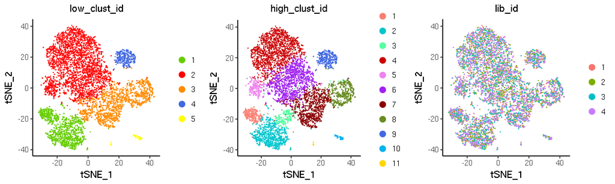

```r
options(repr.plot.width=10, repr.plot.height=3)
lab_groups <- c("low_clust_id", "high_clust_id", "lib_id")
ggs <- lapply(lab_groups, function(lab) {
    g <- plot_scatter_discrete(meta_info, "tSNE_1", "tSNE_2", lab,
                                cust_col=custom_colors(sample_name, lab)) +
          ggtitle(lab)
    return(g)
})
grid.arrange(grobs=ggs, nrow = 1)
tsne_range <- list(x=layer_scales(ggs[[1]])$x$range$range,
                   y=layer_scales(ggs[[1]])$y$range$range)
```

## Load the Gene Expression Matrix

- exprs (dgTMatrix): a sparse matrix of umi counts
- fdata (data.frame): data frame of gene id and symbols
- pdata (data.frame): data frame of cell barcodes

## Cell-type Annotation

The clustering algorithm is tunable and can result in grouping at different resolutions, or simply different number of groups. Therefore, we considered the clusters provided at a low resolution and a high resolution to determine the appropriate number of major cell types. In order to identify the major cell types that are present among the clusters, we performed differential gene analysis to identify cluster specific gene markers. We enumerated genes that are most up-regulated in a given population relative to all the other populations. In particular, we computed the average of the log10 expression of each gene among the cells assigned to a given cluster, and compared this average value to the average log10 expression of the remaining cells in the data after normalization and size correction implemented in sSeq (see Yu, Huber, and Vitek 2013). After analyzing the top genes for each high-resolution cluster, we merged clusters that shared highly expressed genes and annotated 5 major populations, including basal cells, ATII cells and club cells.

We can visualize the most up-regulated genes specific to each cluster in a heat map as follows: Each column in the heat map represents a cell (sorted by the cluster ID) and each row represents a gene that is specific to a cell population (grouped by cluster-specificity, and sorted by fold change from high to low). The color axes correspond to the five clusters and the values are presented in log10 scale. We visualize the upregulated genes for both high and low resolution clustering.

```r
gex_dat_log = load_gex_mtx(file.path(ODIR,  sample_name, "merged_umi_log"))
```

```
[1] "Loaded matrix: 20831 x 7285"
```

```
Plotting matrix of dimension: 25 x 7285
Plotting figure of heatmap area size: 5.000000 x 10.000000
```

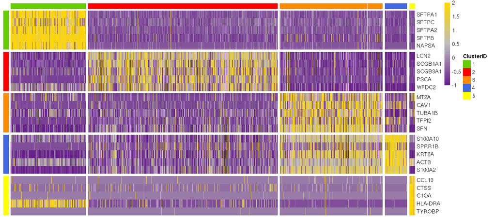

```r
# compute_sub_diff_expr(ODIR, sample_name, meta_info, "low_clust_id")
plot_sub_diff_expr("low_clust_id", disp_genes=5)
```

```
Plotting matrix of dimension: 55 x 7285
Plotting figure of heatmap area size: 11.000000 x 10.000000
```

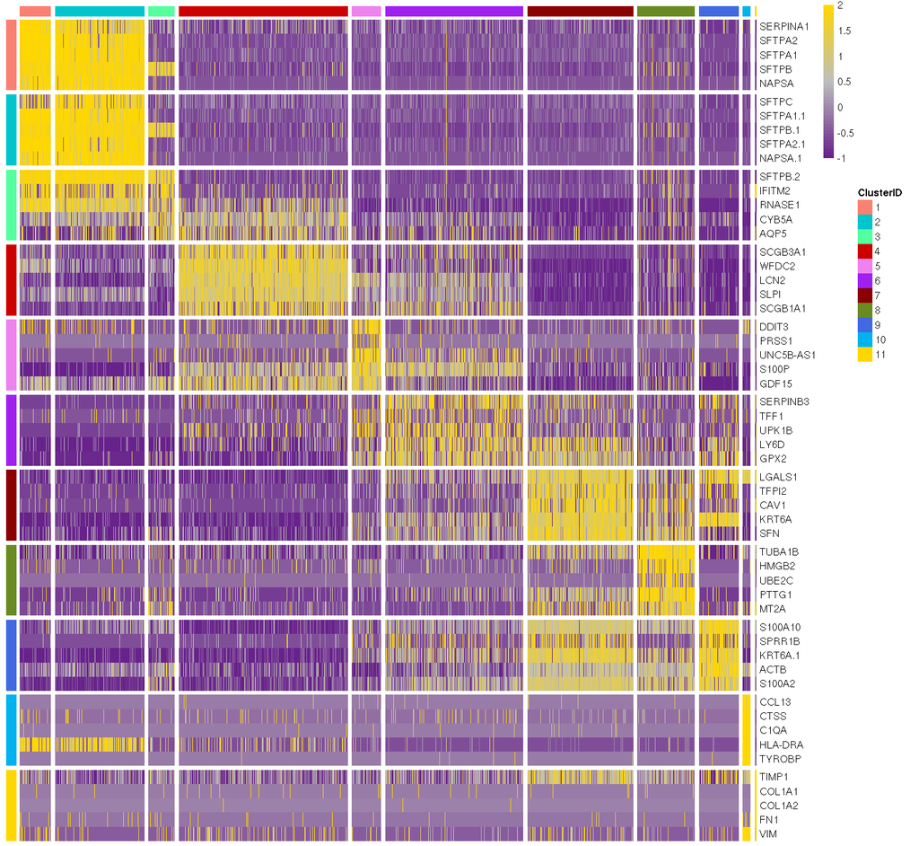

```r
# compute_sub_diff_expr(ODIR, sample_name, meta_info, "high_clust_id")
plot_sub_diff_expr("high_clust_id", disp_genes=5)
```

We start with merging similar clusters from high-resolution clustering results to simplify annotation:

- Clusters 1, 2 and 3 share multiple genes, including SFTPC and SFTPB, incidating a population of alveolar type II (ATII) cells.
- Clusters 7, 8 and 9 share multiple genes, including KRT6A, indicating a population of basal cells.
- Clusters 4, 5 and 6 share relatively high expression of SCGB1A1, indicating a population of club cells.
- Cluster 10 suggests a population of immune cells, given high expression of CTSS and HLA genes.
- Cluster 11 suggests a population of cells that have very high expression of vimentum and collegen.

The merges made among the high-resolution clusters are mostly consistent with the low-resolution clustering result.

```r
lab_type = "major_types"
meta_info[lab_type] <- load_cell_annotation(sample_name, meta_info, lab_type)
cell_sel <- meta_info[[lab_type]] %in% c("ATII", "Basal", "Club")
lab_type <- "major_types_3"
meta_info[lab_type] <- meta_info[["major_types"]]
meta_info[!cell_sel, lab_type] <- "Other"
lab_type <- "major_types_4"
basal_class <- load_cell_annotation(sample_name,  meta_info, "basal_1_vs_2")
meta_info[lab_type] <- meta_info[["major_types_3"]]
basal_sel <- basal_class != "Other"
meta_info[basal_sel, lab_type] <- basal_class[basal_sel]
```

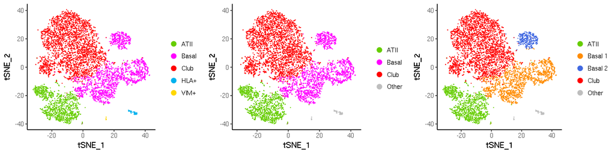

```r
source("src/plotting.R")
options(repr.plot.width=12, repr.plot.height=3)
glist <- lapply(c("major_types", "major_types_3",  "major_types_4"), function(x) {
    plot_scatter_discrete(meta_info, "tSNE_1", "tSNE_2", x,
                      cust_col=custom_colors(sample_name, x))
})
grid.arrange(grobs=glist, nrow = 1)
```

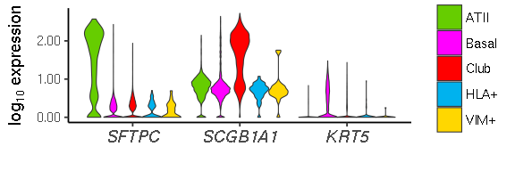

```r
source("src/plotting.R")
known_markers <- c('SFTPC', 'SCGB1A1', 'KRT5')
gviol <- visualize_multiviolin_plots(known_markers,
                            gex_dat_log$exprs[known_markers, ],
                            meta_info[["major_types"]],
                            colour=custom_colors(sample_name, "major_types"))
gviol <- gviol + labs(x='',y=parse(text="log[10]~expression"))
gviol
```

```r
# compute_sub_diff_expr(ODIR, sample_name, meta_info, "major_types_3")
# compute_sub_diff_expr(ODIR, sample_name, meta_info, "major_types")
```

## Plot the Relevant Heat Maps

```
Plotting matrix of dimension: 30 x 7180
Plotting figure of heatmap area size: 6.000000 x 10.000000
```

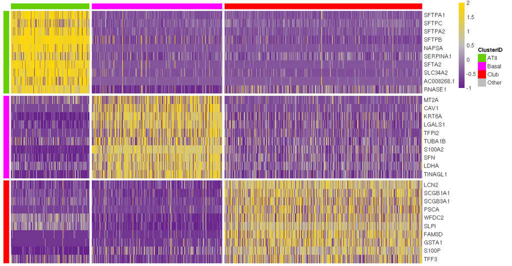

```r
plot_sub_diff_expr("major_types_3")
```

```
Plotting matrix of dimension: 50 x 7285
Plotting figure of heatmap area size: 10.000000 x 10.000000
```

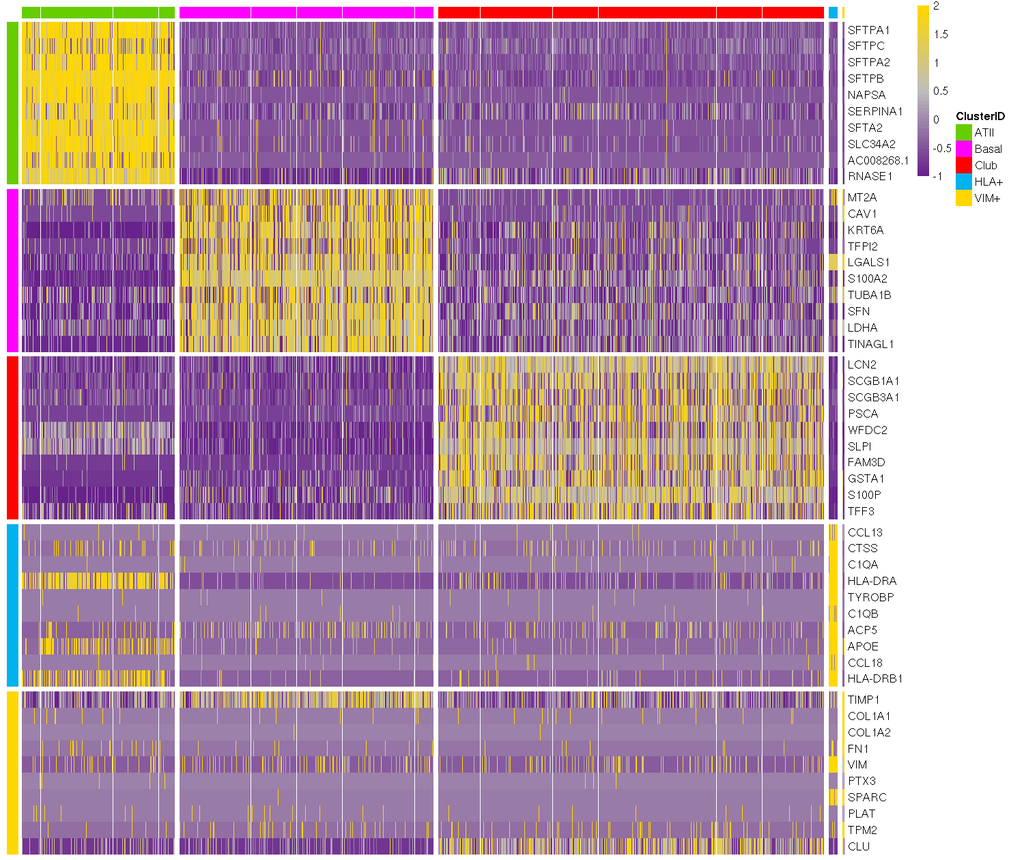

```r
plot_sub_diff_expr("major_types")
```

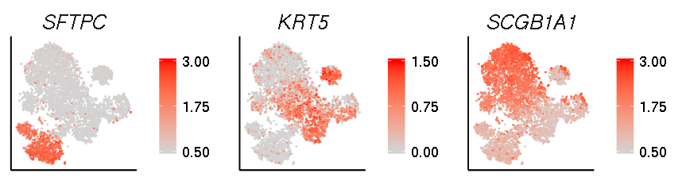

```r
label_type <- "major_types_3"
output_width <- 2.4
output_height <- 1.9
gene_markers <- c('SFTPC', 'KRT5', 'SCGB1A1')
plain_plts <- lapply(gene_markers, function(gene) {
    suppressMessages(manuscript_feat_plots(gene, label_type, meta_info, gex_dat_log, save=FALSE))
})
options(repr.plot.width=output_width*length(gene_markers), repr.plot.height=output_height)
grid.arrange(grobs=plain_plts, nrow = 1)
```

## Sub-populations of Basal Cells

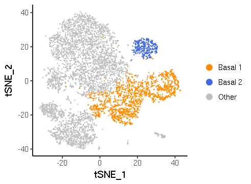

```r
lab_type <-  "basal_1_vs_2"
meta_info[lab_type] <- load_cell_annotation(sample_name, meta_info, lab_type)
options(repr.plot.width=4.1, repr.plot.height=3)
plot_scatter_discrete(meta_info, "tSNE_1", "tSNE_2", lab_type,
                      cust_col=custom_colors(sample_name, lab_type))
# compute_sub_diff_expr(ODIR, sample_name, meta_info, lab_type)
```

```
Plotting matrix of dimension: 20 x 2303
Plotting figure of heatmap area size: 4.000000 x 10.000000
```

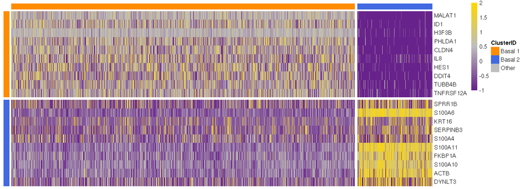

```r
plot_sub_diff_expr(lab_type)
```

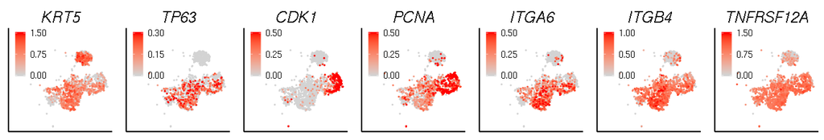

```r
output_width <- 1.6
output_height <- 1.9
source("src/manuscript.R")
gene_markers <- c('KRT5', 'TP63', 'CDK1', 'PCNA', 'ITGA6', 'ITGB4', 'TNFRSF12A')
plain_plts <- lapply(gene_markers, function(gene) {
    suppressMessages(manuscript_feat_plots(gene, "basal_1_vs_2", meta_info, gex_dat_log, save=FALSE))
})
options(repr.plot.width=output_width*length(gene_markers), repr.plot.height=output_height)
grid.arrange(grobs=plain_plts, nrow = 1)
```

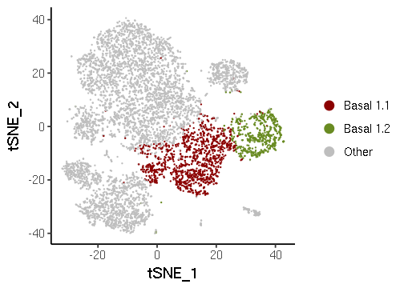

```r
lab_type <-  "basal_11_vs_12"
meta_info[lab_type] <- load_cell_annotation(sample_name, meta_info, lab_type)
options(repr.plot.width=4.2, repr.plot.height=3)
plot_scatter_discrete(meta_info, "tSNE_1", "tSNE_2", lab_type,
                      cust_col=custom_colors(sample_name, lab_type))
# compute_sub_diff_expr(ODIR, sample_name, meta_info, lab_type)
```

```
Plotting matrix of dimension: 20 x 1892
Plotting figure of heatmap area size: 4.000000 x 10.000000
```

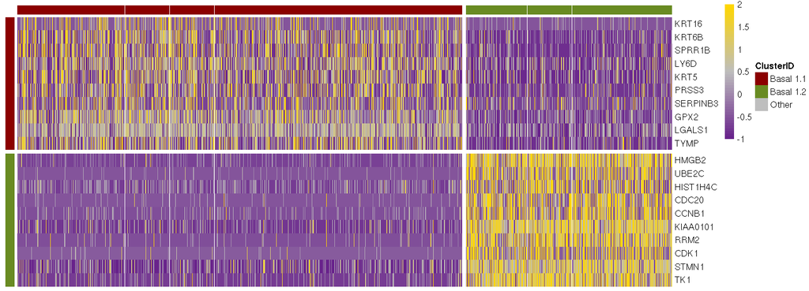

```r
plot_sub_diff_expr(lab_type)
```

## Subpopulations of Type II Cells

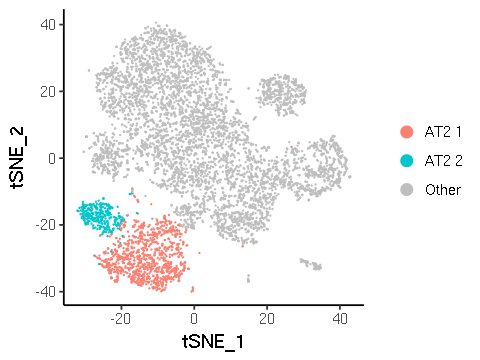

```r
lab_type <-  "at2_1_vs_2"
meta_info[lab_type] <- load_cell_annotation(sample_name, meta_info, lab_type)
options(repr.plot.width=4, repr.plot.height=3)
plot_scatter_discrete(meta_info, "tSNE_1", "tSNE_2", lab_type,
                      cust_col=custom_colors(sample_name, lab_type))
# compute_sub_diff_expr(ODIR, sample_name, meta_info, lab_type)
```

```
Plotting matrix of dimension: 20 x 1387
Plotting figure of heatmap area size: 4.000000 x 10.000000
```

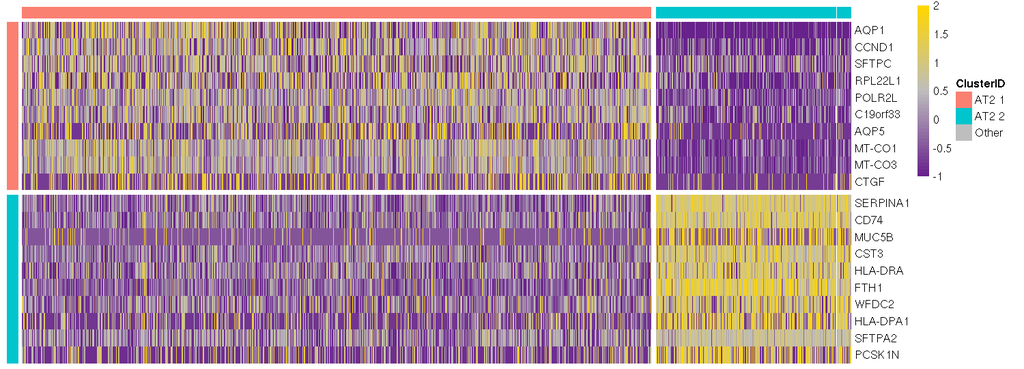

```r
plot_sub_diff_expr(lab_type)
```

## Supplementary 1: Testing Cannonical Marker Genes

Based on our experimental setup and staining experiments, we expected at least three populations (ATII, club and basal) to be present in the data. We wanted to see if the canonical markers for these cell types are significantly differentially expressed across the populations. However, because the expression levels of these same genes were part of the data used to identify cell clusters, naive tests comparing the expression levels of these markers across clusters are not valid.

To work around this issue, we studied how the clusters we identify are dependent on the canonical cell type markers. First, we repeated the unsupervised clustering analyses using the exact same procedure described above on a the scRNA-seq data excluding measurements for each of the marker genes. This yields clustering assignments that are “independent” of the marker gene (given the correlation that exists among the expression of many genes, we are not referring here to stochastic independence). We compared the low-resolution clusters (parameter 0.1 for the graph based clustering) obtained with and without each of the marker genes. After verifying that the clustering results were highly consistent according to multiple clustering concordant metrics, we used Kruskal-Wallis Rank Sum Test to test if a known marker gene is differentially expressed across all populations based on the clusters that did not utilize information of the marker gene (with the null hypothesis that the mean expression of a given gene is the same across all groups.) Note p-value = 0 in R indicates p-value <1e-300 in the reported results.

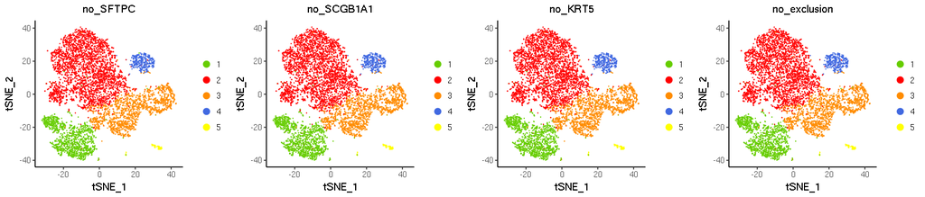

```r
# load the data
source('src/plotting.R')
fname <- "exclusion_clustering_result.tsv"
fname <- file.path(ODIR, sample_name, "supplementary", fname)
test_clust_df <- read.table(fname, header=TRUE)
lab_groups <- c("no_SFTPC", "no_SCGB1A1", "no_KRT5", "no_exclusion")
ggs <- lapply(lab_groups, function(lab) {
    df <- merge(test_clust_df, meta_info, by="barcode")
    g <- plot_scatter_discrete(df, "tSNE_1", "tSNE_2", lab,
                               cust_col=custom_colors(sample_name, lab)) +
          ggtitle(lab)
    return(g)
})
options(repr.plot.width=14, repr.plot.height=3)
grid.arrange(grobs=ggs, nrow = 1)
```

```r
known_genes <- c("SCGB1A1", "KRT5", "SFTPC")
kruskal.test.res <- do.call(cbind, lapply(known_genes, function(gene) {
  gene_df <- t(as.matrix(gex_dat_log$exprs[gene, , drop=FALSE]))
  rownames(gene_df) <- NULL
  gene_df <- data.frame(gene_df)
  colnames(gene_df) <- 'gene'
  gene_df$ID <- as.factor(test_clust_df[,sprintf("no_%s", gene)])
  test = 'kruskal.test'
  res <- kruskal.test(gene ~ ID, data=gene_df)
  return(res[c('statistic','p.value')])
}))
colnames(kruskal.test.res) = known_genes
print(kruskal.test.res)
```

```
          SCGB1A1  KRT5          SFTPC
statistic 2798.404 1382.041      1911.177
p.value   0        5.416676e-298 0
```

## Supplementary 2: Associating TNFRSF12A with Proliferative Markers

To understand the role of TNFRSF12A, we investigated associations between expression levels of TNFRSF12A and known proliferative markers both experimentally and computationally. Experimentally, the canonical basal cells would be sorted by the presence of three joint basal markers: ITGA6+, ITGB4+ and EPCAM+. Next, the cells among these sorted cells would be further separated into a TNFRSF12A low and a TNFRSF12A high group and independently cultured, to measure cell growth . To mimic computationally this approach and explore its outcome on the basis of the scRNA-seq data, we selected all cells that had basal markers, and then we divided the cells into two groups defined by the top and bottom quartiles of TNFRSF12A expression. Finally, we tested if the presence of a proliferative marker (found in the literature) is associated with the these two cells groups (TNFRSF12A high and TNFRSF12A low) using a Chi-square test for independence.

Next, the cells among these sorted cells would be further separated and independently cultured by TNFRSF12A low and TNFRSF12A high. To investigate the implications of approach, we computationally selected all cells that had basal markers, and then we grouped the cells into two groups by selecting the top and low quartile based on TNFRSF12A expression.

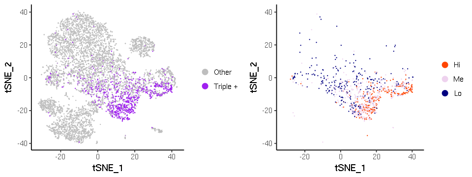

```r
source("src/plotting.R")
source("src/utils.R")
pos_neg <- apply(gex_dat_log$exprs[c('ITGA6','ITGB4','EPCAM'),],2, prod) > 0
meta_info["basal_facs"] <- ifelse(pos_neg, "Triple +", "Other")
sub_meta_info <- meta_info[pos_neg, ]
sub_meta_info["TNFRSF12A_level"] <- quant_assignment(gex_dat_log$exprs["TNFRSF12A", pos_neg], 25)
g_facs <- lapply(c("basal_facs", "TNFRSF12A_level"), function(lab_type) {
    if (lab_type == "TNFRSF12A_level") {
        plot_df <- sub_meta_info
    } else {
        plot_df <- meta_info
    }
    g <- plot_scatter_discrete(plot_df, "tSNE_1", "tSNE_2", lab_type,
                             cust_col=custom_colors(sample_name, lab_type))
    g <- g + xlim(tsne_range$x) + ylim(tsne_range$y)

})
options(repr.plot.width=8, repr.plot.height=3)
grid.arrange(grobs=g_facs, nrow = 1, widths=c(4.0, 3.7))
```

```
Gene: MKI67,	p-value: 0.000000
Gene: MYBL2,	p-value: 0.000001
Gene: PLK1,	p-value: 0.000000
Gene: BUB1,	p-value: 0.000002
Gene: E2F1,	p-value: 0.443925
Gene: FOXM1,	p-value: 0.000286
```

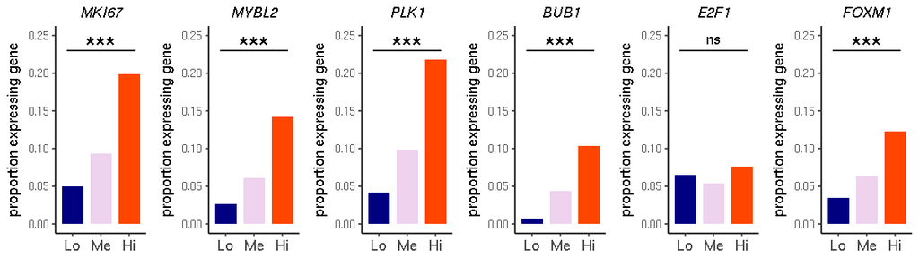

```r
source("src/plotting.R")
prolif_genes = c('MKI67','MYBL2','PLK1','BUB1','E2F1', 'FOXM1')
show_axes = TRUE
prolif_plots = lapply(prolif_genes, function(gene) {
  # two factors: prolif gene (+/-) and tweakR level (high/med/low)
  pos = gex_dat_log$exprs[gene,pos_neg] > 0
  gene_marker = rep('-',length(pos))
  gene_marker[pos] = '+'
  gene_marker = factor(gene_marker,c('+','-'))
  # chi-square test
  tbl <- table(sub_meta_info[["TNFRSF12A_level"]], gene_marker)
  chi2res = chisq.test(tbl)
  p.value = chi2res$p.value
  cat(sprintf("Gene: %s,\tp-value: %f\n",gene, p.value))
  # plot the bar plots
  p = prolif_barplots2(sub_meta_info[["TNFRSF12A_level"]],
                       gene_marker, p.value, rev(custom_colors(sample_name, "TNFRSF12A_level")),
                       gene_name = gene, show_axes = show_axes)
  return(p)
})
options(repr.plot.width=10, repr.plot.height=3)
grid.arrange(grobs=prolif_plots, nrow = 1)
```